# Target-seq analysis - Patient IF137

### Summary for single-cells

```r
cDNA_vcf <- cDNA_vcf %>%
      mutate (status = ifelse (is.na(SDP) | (as.numeric(SDP) < 31), 3,
                       ifelse (RD > 10 & vaf < seuil_mut, 0,
                       ifelse (AD < 10 & vaf > seuil_mut, 0,
                       ifelse (AD > 10 & RD > 10 &  vaf < (1 - seuil_mut) & vaf > seuil_mut, 1,
                       ifelse (AD > 10 & vaf > (1 - seuil_mut), 2,
                       ifelse (RD < 10 & vaf < (1 - seuil_mut), 2, 3)))))))

summary_cDNA <- cDNA_vcf %>%
  select (MUT, cell_ID, status) %>%
  pivot_wider (names_from = MUT, values_from = status) %>%
  mutate (cell_ID = cell_id)
```

# Consensus mutationnal status

## Integration of cDNA and gDNA for amplicons with both read-out

```r
integration_U2AF1 <- data.frame(summary_cDNA$U2AF1_Q157R, summary_gDNA$U2AF1_Q157R)

integration_U2AF1 <- integration_U2AF1 %>%
      mutate (summary = ifelse(summary_gDNA.U2AF1_Q157R == 3, integration_U2AF1$summary_cDNA.U2AF1_Q157R,
                        ifelse(summary_cDNA.U2AF1_Q157R == 3, integration_U2AF1$summary_gDNA.U2AF1_Q157R,
                        ifelse(summary_cDNA.U2AF1_Q157R == 1 | summary_gDNA.U2AF1_Q157R == 1, 1,
                        ifelse(summary_cDNA.U2AF1_Q157R == 0 & summary_gDNA.U2AF1_Q157R == 0, 0,
                        ifelse(summary_cDNA.U2AF1_Q157R == 2 & summary_gDNA.U2AF1_Q157R == 2, 2,
                        ifelse(summary_cDNA.U2AF1_Q157R == 0 & summary_gDNA.U2AF1_Q157R == 2, 1,
                        ifelse(summary_cDNA.U2AF1_Q157R == 2 & summary_gDNA.U2AF1_Q157R == 0, 1,"A explorer"))))))))


#summary(as.factor(integration_U2AF1$summary))
```

```r
integration_TET2 <- data.frame(summary_cDNA$TET2_I1105M, summary_gDNA$TET2_I1105M)

integration_TET2 <- integration_TET2 %>%
      mutate (summary = ifelse(summary_gDNA.TET2_I1105M==3, integration_TET2$summary_cDNA.TET2_I1105M,
                        ifelse(summary_cDNA.TET2_I1105M==3, integration_TET2$summary_gDNA.TET2_I1105M,
                        ifelse(summary_cDNA.TET2_I1105M == 1 | summary_gDNA.TET2_I1105M == 1, 1,
                        ifelse(summary_cDNA.TET2_I1105M == 0 & summary_gDNA.TET2_I1105M == 0, 0,
                        ifelse(summary_cDNA.TET2_I1105M == 2 & summary_gDNA.TET2_I1105M == 2, 2,
                        ifelse(summary_cDNA.TET2_I1105M == 0 & summary_gDNA.TET2_I1105M == 2, 1,
                        ifelse(summary_cDNA.TET2_I1105M == 2 & summary_gDNA.TET2_I1105M == 0, 1,"A explorer"))))))))


#summary(as.factor(integration_TET2$summary))
```

```r
integration_JAK2 <- data.frame(summary_cDNA$JAK2_V617F, summary_gDNA$JAK2_V617F)

integration_JAK2 <- integration_JAK2 %>%
      mutate (summary = ifelse(summary_gDNA.JAK2_V617F==3, integration_JAK2$summary_cDNA.JAK2_V617F,
                        ifelse(summary_cDNA.JAK2_V617F==3, integration_JAK2$summary_gDNA.JAK2_V617F,
                        ifelse(summary_cDNA.JAK2_V617F == 1 | summary_gDNA.JAK2_V617F == 1, 1,
                        ifelse(summary_cDNA.JAK2_V617F == 0 & summary_gDNA.JAK2_V617F == 0, 0,
                        ifelse(summary_cDNA.JAK2_V617F == 2 & summary_gDNA.JAK2_V617F == 2, 2,
                        ifelse(summary_cDNA.JAK2_V617F == 0 & summary_gDNA.JAK2_V617F == 2, 1,
                        ifelse(summary_cDNA.JAK2_V617F == 2 & summary_gDNA.JAK2_V617F == 0, 1,"A explorer"))))))))


#summary(as.factor(integration_JAK2$summary))
```

```r
summary_genotypes <- summary_gDNA %>%
      mutate (U2AF1_Q157R = as.numeric(integration_U2AF1$summary),
              TET2_I1105M = as.numeric(integration_TET2$summary),
              JAK2_V617F = as.numeric(integration_JAK2$summary))

summary_SCITE <- summary_genotypes %>%
      select (- cell_ID)

#write.table(summary_genotypes, "summary_genotype_IF0137.tsv", sep = "\t", row.names = F, col.names = T)

#write.table(t(summary_SCITE), "summary_SCITEIF0137def.tsv", sep = " ", row.names = F, col.names = F)
```

## Comparison with published data

```r
 published <- read.csv2("metadata_for_seurat.csv", sep = ";", stringsAsFactors = F)

published <- published %>%
  rowwise () %>%
  mutate (ASXL1_W898R_published = ifelse (cell_id_dnaseq %in%  (published[grep("ASXL1_p897_HET", published$published_genotype),"cell_id_dnaseq"]), 1,
                        ifelse (cell_id_dnaseq %in%  (published[grep("ASXL1_p897_HOM", published$published_genotype),"cell_id_dnaseq"]), 2, 0)),
          ASXL1_Q910A_published = ifelse (cell_id_dnaseq %in%  (published[grep("ASXL1_p910_HET", published$published_genotype),"cell_id_dnaseq"]), 1,
                        ifelse (cell_id_dnaseq %in%  (published[grep("ASXL1_p910_HOM", published$published_genotype),"cell_id_dnaseq"]), 2, 0)),
          U2AF1_Q157R_published = ifelse (cell_id_dnaseq %in%  (published[grep("U2AF1_HET", published$published_genotype),"cell_id_dnaseq"]), 1,
                        ifelse (cell_id_dnaseq %in%  (published[grep("U2AF1_HOM", published$published_genotype),"cell_id_dnaseq"]), 2, 0)),
          TET2_I1105M_published = ifelse (cell_id_dnaseq %in%  (published[grep("TET2_pI1105_HET", published$published_genotype),"cell_id_dnaseq"]), 1,
                        ifelse (cell_id_dnaseq %in%  (published[grep("TET2_pI1105_HOM", published$published_genotype),"cell_id_dnaseq"]), 2, 0)),
          JAK2_V617F_published = ifelse (cell_id_dnaseq %in%  (published[grep("JAK2_HET", published$published_genotype),"cell_id_dnaseq"]), 1,
                        ifelse (cell_id_dnaseq %in%  (published[grep("JAK2_HOM", published$published_genotype),"cell_id_dnaseq"]), 2, 0)))

comparison <- summary_genotypes %>%
    left_join(published, by = c("cell_ID"="cell_id_dnaseq")) %>%
    dplyr::rowwise() %>%
    mutate (ASXL1_W898R_comparison = identical(ASXL1_W898R_published, ASXL1_W898R),
            ASXL1_Q910A_comparison = identical(ASXL1_Q910A_published, ASXL1_Q910A),
            U2AF1_Q157R_comparison = identical(U2AF1_Q157R_published, U2AF1_Q157R),
            TET2_I1105M_comparison = identical(TET2_I1105M_published, TET2_I1105M),
            JAK2_V617F_comparison = identical(JAK2_V617F_published, JAK2_V617F))

comparison  %>%
    select(ASXL1_W898R_comparison, ASXL1_Q910A_comparison, U2AF1_Q157R_comparison, TET2_I1105M_comparison,JAK2_V617F_comparison) %>%
    pivot_longer(everything(), names_to = "mutations", values_to = "status") %>%
   group_by(mutations, status) %>%
  count()
```

```
# A tibble: 10 x 3
# Groups:   mutations, status [10]
   mutations              status     n
   <chr>                  <lgl>  <int>
 1 ASXL1_Q910A_comparison FALSE      2
 2 ASXL1_Q910A_comparison TRUE     615
 3 ASXL1_W898R_comparison FALSE      2
 4 ASXL1_W898R_comparison TRUE     615
 5 JAK2_V617F_comparison  FALSE     23
 6 JAK2_V617F_comparison  TRUE     594
 7 TET2_I1105M_comparison FALSE      1
 8 TET2_I1105M_comparison TRUE     616
 9 U2AF1_Q157R_comparison FALSE     12
10 U2AF1_Q157R_comparison TRUE     605
```

### Discripancies on JAK2

```r
disc_jak2 <-  comparison %>%filter (JAK2_V617F_comparison == FALSE) %>% select (cell_ID, JAK2_V617F, JAK2_V617F_published)

gDNA_data %>%
  filter (MUT == "JAK2_V617F") %>%
  mutate (cell_ID = cell_id) %>%
  select(MUT, cell_ID, AD, RD, FREQ) %>%
  left_join (cDNA_vcf %>%   filter (MUT == "JAK2_V617F") %>% mutate (cell_ID = cell_id) %>% select(MUT, cell_ID, AD, RD, FREQ), by = c("cell_ID", "MUT")) %>%
  right_join (disc_jak2, by = "cell_ID")
```

```
# A tibble: 23 x 10
   MUT   cell_ID  AD.x  RD.x FREQ.x  AD.y  RD.y FREQ.y JAK2_V617F
   <chr> <chr>   <dbl> <dbl> <chr>  <dbl> <dbl> <chr>       <dbl>
 1 JAK2… SRR815… 25209    71 99.44%   154   174 46.95%          1
 2 JAK2… SRR815…    77 40867 0.19%     33  1622 1.99%           1
 3 JAK2… SRR815…    53 18013 0.29%     47   122 27.49%          1
 4 JAK2… SRR815… 68596   248 99.45%   248    39 86.41%          1
 5 JAK2… SRR815…    92 54227 0.17%    144  6656 2.12%           1
 6 JAK2… SRR815… 36076   121 99.39%    19    25 43.18%          1
 7 JAK2… SRR815… 56012   195 99.52%  2669    62 97.3%           1
 8 JAK2… SRR815…    79 29206 0.27%     51    45 53.12%          1
 9 JAK2… SRR815…    67 36045 0.19%    103   591 14.84%          1
10 JAK2… SRR815… 24270    64 99.37%   194    13 93.72%          1
# … with 13 more rows, and 1 more variable: JAK2_V617F_published <dbl>
```

### Discripancies on U2AF1

```r
disc_u2af1 <-  comparison %>%filter (U2AF1_Q157R_comparison == FALSE) %>% select (cell_ID, U2AF1_Q157R, U2AF1_Q157R_published)

gDNA_data %>%
  filter (MUT == "U2AF1_Q157R") %>%
  mutate (cell_ID = cell_id) %>%
  select(MUT, cell_ID, AD, RD, FREQ) %>%
  left_join (cDNA_vcf %>%   filter (MUT == "U2AF1_Q157R") %>% mutate (cell_ID = cell_id) %>% select(MUT, cell_ID, AD, RD, FREQ), by = c("cell_ID", "MUT")) %>%
  right_join (disc_u2af1, by = "cell_ID")
```

```
# A tibble: 12 x 10
   MUT   cell_ID  AD.x  RD.x FREQ.x  AD.y  RD.y FREQ.y U2AF1_Q157R
   <chr> <chr>   <dbl> <dbl> <chr>  <dbl> <dbl> <chr>        <dbl>
 1 U2AF… SRR815…     5    46 9.8%       8   193 3.98%            0
 2 U2AF… SRR815…  6383   117 98.18%    NA    NA <NA>             1
 3 U2AF… SRR815… 19644   114 99.33%     2    70 2.78%            1
 4 U2AF… SRR815…  2191    68 96.99%    14    11 56%              1
 5 U2AF… SRR815…     5   312 1.58%     33     0 100%             1
 6 U2AF… SRR815…    44  1422 3%         2    15 11.76%           1
 7 U2AF… SRR815…   442 18521 2.33%     80     7 91.95%           1
 8 U2AF… SRR815…    11   653 1.66%     22  4601 0.48%            1
 9 U2AF… SRR815…  1015    18 98.26%    96     2 97.96%           1
10 U2AF… SRR815…   111  3203 3.35%      1    26 3.7%             1
11 U2AF… SRR815…     9    30 23.08%   114 10554 1.07%            0
12 U2AF… SRR815…     9    81 10%       NA    NA <NA>             0
# … with 1 more variable: U2AF1_Q157R_published <dbl>
```

# Clonal identity assignation

## Clonal architecture inference using inf SCITE

We used infiny-SCITE (Kuipers, J., Jahn, K., Raphael, B. J., & Beerenwinkel, N. (2017). Single-cell sequencing data reveal widespread recurrence and loss of mutational hits in the life histories of tumors. Genome research, 27(11), 1885-1894.)

Given the noisy mutation profiles of single cells, ∞SCITE performs a stochastic search to find the Maximum Likelihood (ML) or Maximum aposterori (MAP) tree and/or to sample from the posterior probability distribution. Tree reconstruction can be combined with an estimation of the error and doublet rates in the mutation profiles.

```bash
./infSCITE -i summary_SCITEIF0137def.tsv -n 5 -m 617 -r 1 -l 900000 -fd 0.001 -ad 0.01 0.01 -cc 0 -names IF0137.geneNames
```

Only one tree was retained, very similar to what the authors obtained (inf-SCITE do not represent homozyguous mutations)

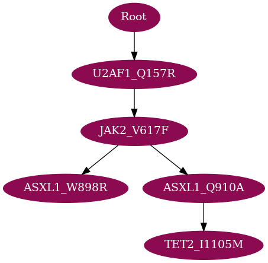

## Clonal identity assignation

```r
# We annotate the genotype, JAK2 is the only mutation with enough cells with homozygous genotype, so zygosity will be ignore for other cells and HOM cells will be considered as drop-out
clone_identity <- summary_genotypes %>%
            mutate (clone = as.factor(ifelse (U2AF1_Q157R == 0 & JAK2_V617F == 0 & ASXL1_W898R == 0 & ASXL1_Q910A == 0 & TET2_I1105M == 0, "WT",
                                ifelse ((U2AF1_Q157R == 1 |  U2AF1_Q157R == 2) & JAK2_V617F == 0 & ASXL1_W898R == 0 & ASXL1_Q910A == 0 & TET2_I1105M == 0, "U2AF1_HET",
                                ifelse (JAK2_V617F == 1 & ASXL1_W898R == 0 & ASXL1_Q910A == 0 & TET2_I1105M == 0, "U2AF1_HET_JAK2_HET",
                                ifelse (JAK2_V617F == 2 & ASXL1_W898R == 0 & ASXL1_Q910A == 0 & TET2_I1105M == 0, "U2AF1_HET_JAK2_HOM",
                                ifelse ((ASXL1_W898R == 1 | ASXL1_W898R == 2) & ASXL1_Q910A == 0 & TET2_I1105M == 0, "U2AF1_HET_JAK2_HET_ASXL1_W898_HET",
                                ifelse (ASXL1_W898R == 0 & (ASXL1_Q910A == 1 | ASXL1_Q910A == 2)  & TET2_I1105M == 0, "U2AF1_HET_JAK2_HET_ASXL1_Q910A_HET",
                                ifelse (ASXL1_W898R == 0 & (TET2_I1105M == 1 | TET2_I1105M == 2) , "U2AF1_HET_JAK2_HET_ASXL1_Q910A_HET_TET2_HET", NA)))))))))

# we resolve conflicting genotype by inspecting vcf
#clone_identity %>% filter (is.na(clone))
#(gDNA_data %>% filter (MUT == "ASXL1_Q910A"))[is.na(clone_identity$clone),]
clone_identity <- clone_identity %>% mutate (clone = as.factor(ifelse (is.na(clone) & cell_ID == "SRR8153744", "U2AF1_HET_JAK2_HET_ASXL1_Q910A_HET_TET2_HET",
                                   ifelse (is.na(clone) & cell_ID == "SRR8154974", "U2AF1_HET_JAK2_HET_ASXL1_Q910A_HET", as.character(clone)))))


data.frame(summary(clone_identity$clone))
```

```
                                            summary.clone_identity.clone.
U2AF1_HET                                                              13
U2AF1_HET_JAK2_HET                                                    279
U2AF1_HET_JAK2_HET_ASXL1_Q910A_HET                                     76
U2AF1_HET_JAK2_HET_ASXL1_Q910A_HET_TET2_HET                           121
U2AF1_HET_JAK2_HET_ASXL1_W898_HET                                      77
U2AF1_HET_JAK2_HOM                                                     39
WT                                                                     12
```

## Comparison with published clone assignation

```r
published_clone <- published %>%
  mutate (published_genotype = ifelse (published_genotype == "JAK2_WT", "WT",
                               ifelse (published_genotype %in% c("JAK2_WT_U2AF1_HET", "JAK2_WT_U2AF1_HOM"), "U2AF1_HET",
                               ifelse (published_genotype %in% c("JAK2_HET", "JAK2_HET_U2AF1_HET", "JAK2_HET_U2AF1_HOM"), "U2AF1_HET_JAK2_HET",
                               ifelse (published_genotype %in% c("JAK2_HOM", "JAK2_HOM_U2AF1_HET", "JAK2_HOM_U2AF1_HOM"), "U2AF1_HET_JAK2_HOM",
                               ifelse (published_genotype %in% c("JAK2_HET_U2AF1_HOM_ASXL1_p897_HET",  "JAK2_WT_U2AF1_HET_ASXL1_p897_HET", "JAK2_HET_ASXL1_p897_HET", "JAK2_HET_U2AF1_HET_ASXL1_p897_HET", "JAK2_HOM_U2AF1_HET_ASXL1_p897_HET", "JAK2_WT_U2AF1_HET_ASXL1_p897_HOM" ), "U2AF1_HET_JAK2_HET_ASXL1_W898_HET",
                               ifelse (published_genotype %in% c("JAK2_HET_U2AF1_HET_ASXL1_p910_HET", "JAK2_HOM_U2AF1_HET_ASXL1_p910_HET", "JAK2_WT_U2AF1_HET_ASXL1_p910_HET", "JAK2_HET_U2AF1_HOM_ASXL1_p910_HET", "JAK2_HET_ASXL1_p910_HET"), "U2AF1_HET_JAK2_HET_ASXL1_Q910A_HET", "U2AF1_HET_JAK2_HET_ASXL1_Q910A_HET_TET2_HET"))))))) %>%
  right_join (clone_identity %>% select (cell_ID, clone), by = c( "cell_id_dnaseq" = "cell_ID")) %>%
  select (-well, -cell_id_dnaseq)

#table(published_clone$clone, published_clone$published_genotype)

summary(published_clone$clone ==  published_clone$published_genotype)
```

```
   Mode   FALSE    TRUE
logical      22     595
```

```r
#write.table(published_clone, "metadata_for_seurat_final.csv", sep = ";", dec = ".", col.names = T, row.names = F)

xtab <- table(published_clone$clone, published_clone$published_genotype)
diagonal.counts <- diag(xtab)
N <- sum(xtab)
row.marginal.props <- rowSums(xtab)/N
col.marginal.props <- colSums(xtab)/N
# Calculer kappa (k)
Po <- sum(diagonal.counts)/N
Pe <- sum(row.marginal.props*col.marginal.props)
k <- (Po - Pe)/(1 - Pe)
k
```

```
[1] 0.9513121
```